# Guia Tarea 4

### FI3104-1 Métodos Numéricos para la Ciencia e Ingeniería

**Profesor**: Andrés Meza

**Auxiliares**: Javiera Ahumada, Víctor Navarro

A continuación se muestra un caso de ejemplo para la utilización de K-Means vía **scikit-learn**

```python
from astropy.io import fits
import numpy as np
import matplotlib.pyplot as plt
import pandas as pd
from sklearn.cluster import KMeans
```

```python
# Solo para mostrar las versiones
import pkg_resources
import sklearn
import sys
print "Escrito en Python", sys.version
print "NumPy version:", pkg_resources.get_distribution("numpy").version
print "AstroPy version:", pkg_resources.get_distribution("astropy").version
print "Scikit-Learn version:", sklearn.__version__
```

```
Escrito en Python 2.7.13 |Anaconda 4.3.0 (64-bit)| (default, Dec 19 2016, 13:29:36) [MSC v.1500 64 bit (AMD64)]
NumPy version: 1.11.3
AstroPy version: 1.3
Scikit-Learn version: 0.18.1
```

## Abriendo archivos .FITS

Hay varias formas de abrir un archivo fits. La forma usual es abrirlo mediante *astropy.io.fits*:

```python
hdul = fits.open('example.fits') # abrimos el archivo example.fits
hdul.info() # vemos la información
```

```
Filename: example.fits
No.    Name         Type      Cards   Dimensions   Format
  0  PRIMARY     PrimaryHDU       4   ()
  1              BinTableHDU     12   1500R x 2C   [D, D]
```

De acá podemos observar que hdul tiene dos componentes. Para seleccionar la tabla que contiene *example.fits* debemos de elegir la de tipo BinTableHDU (esto puede variar, pero basta con fijarse en las dimensiones).

Notar que se tienen 1500 filas y 2 columnas. Para recuperar los datos de la tabla se procede como sigue:

```python
X = hdul[1].data
X = np.array(X).byteswap().newbyteorder() # Transformamos el formato de bits del archivo fits a uno legible por Numpy o Pandas
```

Los nombres de las columnas en este caso son 'x' e 'y'. La información de la tabla se puede almacenar en un array de NumPy usando *np.array(X)*. Sin embargo, yo prefiero la utilización de Pandas y sus DataFrames:

```python
df = pd.DataFrame(X)
df.columns # Nos entrega las columnas del DataFrame
```

```
Index([u'x', u'y'], dtype='object')
```

Un DataFrame es similar a una planilla de cálculo, podemos imprimir los primeros 5 elementos de este usando el método *head()*:

```python
df.head()
```

|  | x | y |
| --- | --- | --- |
| 0 | 8.433566 | -3.882982 |
| 1 | 2.022605 | -2.398389 |
| 2 | 6.229294 | -9.944140 |
| 3 | 0.710372 | -0.203361 |
| 4 | 5.227370 | -10.689155 |

Si queremos ver la fila n-ésima, basta con usar el método *loc[n]:

```python
n= 6
df.loc[n] # n-ésima fila
```

```
x   -0.909187
y    0.058062
Name: 6, dtype: float64
```

También podemos obtener una columna completa:

```python
# Podemos usar df.nombre_columna o df.['nombre_columna'], ambos entregan lo mismo
assert df.x.all() == df['x'].all() # Arroja un error si esto es incorrecto

x_list = df.x.tolist() # Lo transformamos a lista
x_list[:5] # Primeros 5 elementos de la columna x
```

```
[8.433566317694401,
 2.0226050856547,
 6.229294490324303,
 0.7103716276363281,
 5.227370305246385]
```

Si queremos iterar sobre las filsa de un DataFrame, usamos el método *iterrows()*. A continuación se generará una copia del DataFrame actual y se eliminarán las 2 primeras filas:

```python
new_df = df # copia del DataFrame
for index, row in new_df.iterrows():
    if index==2: # Si pasamos a la fila con índice 2 rompemos el ciclo
        break
    new_df = new_df.drop(index) # Eliminamos la fila con índice index
new_df.head()
```

|  | x | y |
| --- | --- | --- |
| 2 | 6.229294 | -9.944140 |
| 3 | 0.710372 | -0.203361 |
| 4 | 5.227370 | -10.689155 |
| 5 | 3.892683 | -8.970145 |
| 6 | -0.909187 | 0.058062 |

Finalmente, podemos plotear ambas columnas:

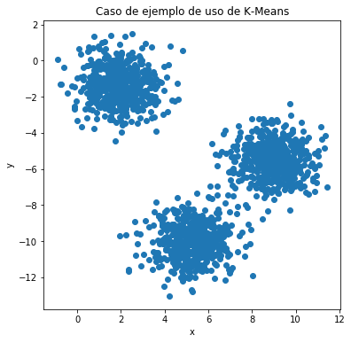

```python
plt.figure(figsize=(6, 6)) # Le asignamos un tamaño
plt.scatter(df.x, df.y) # graficamos los puntos
plt.title('Caso de ejemplo de uso de K-Means')
plt.xlabel('x') # eje x
plt.ylabel('y') # eje y
plt.show()
```

## Scikit-Learn

La biblioteca **sklearn** es un conjunto de clases y métodos utilizados en Machine Learning. La API de los métodos es prácticamente la misma para cada clase, así, la utilización de la biblioteca se te hará familiar sobre cualquier clase.

De la página de *scikit-learn* podemos ver por ejemplo los distintos tipos de clustering: https://scikit-learn.org/stable/modules/classes.html#module-sklearn.cluster

### K-Means

K-means es un método de clustering que va computando k centroides por cada iteración hasta obtener un óptimo para los puntos de tal forma que la distancia entre punto y el centroide más cercano deje de variar (ver https://www.youtube.com/watch?v=BVFG7fd1H30). El número de iteraciones dependerá principalmente en la distribución de los puntos y en la asignación de los centroides iniciales.

Si entramos a mirar la clase, hay dos parámetros que en un principio son importantes:

- *n_clusters* : número de cluster que el algoritmo buscará.
- *random_state*: es una semilla para los números aleatorios y determina la generación aleatoria de los centros del algoritmo. Es **importante** definirlo para que el resultado sea replicable cada vez que se corra el código.

Cuando mencionp que la API de los métodos es similar, me refiero a los métodos de entrenamiento y predicción:

- *fit(X)* : Computa el algoritmo de k-means usando de base el argumento X
- *predict(X)* : Predice el cluster más cercano a cada uno de los puntos dados por el argumento X, retorna una lista con los resultados.
- *fit_predict(X)* : Equivale a llamar *fit(X)* y *predict(X)* en una línea.

Justamente estos mismos métodos encontrarán por ejemplo en *GaussianMixture*, en otro tipo de clustering, regresiones y métodos de clasificación.

#### K-Means sobre nuestro .fits

Cuando ploteamos las columnas 'x' e 'y' vimos con claridad que el número de clusters debería de ser 3. Sin embargo esto no siempre será así, puede que los datos requieran de una limpieza previa (eliminación de outliers y de ruido) antes de pasar a k-means. Solo para ver el funcionamiento de K-means pasaremos a obtener 9 clusters:

```python
k=9 # número de clusters
kmeans = KMeans(n_clusters=k, random_state=1) # clusters
y_pred = kmeans.fit_predict(df)
```

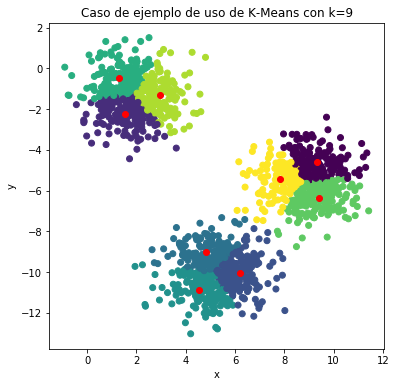

```python
plt.figure(figsize=(6, 6))
plt.scatter(df.x, df.y, c=y_pred) # graficamos los puntos con colores segun y_pred
for center in kmeans.cluster_centers_:
    plt.plot(center[0],center[1],'or') # graficamos los centros
plt.title('Caso de ejemplo de uso de K-Means con k=%i' %k)
plt.xlabel('x') # eje x
plt.ylabel('y') # eje y
plt.show()
```